# 2021 Annual Bacteria Beach Report

Connecticut Department of Energy and Environmental Protection

Report Created: February 2023

## 2021 Summary

[interactive chart not shown]

*Note: Bacteria results available for download in this map are from samples collected from each of the state-owned swimming areas for the most recent year available.To download bacteria results from all state-owned swimming areas for the most recent year, click here.*

## 2021 Closures

### Number of Closures

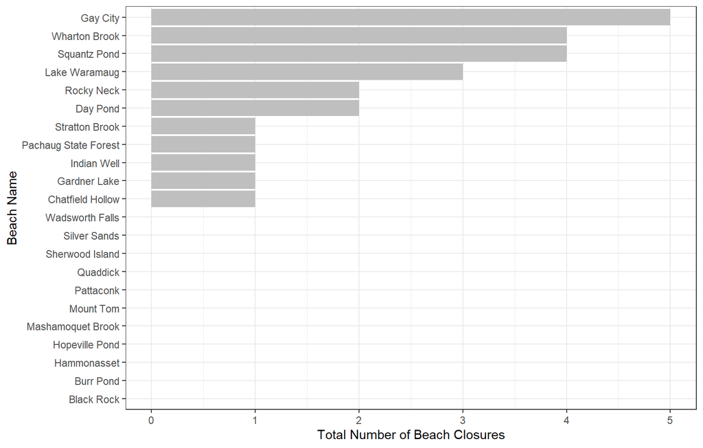

### Number of Days Closed

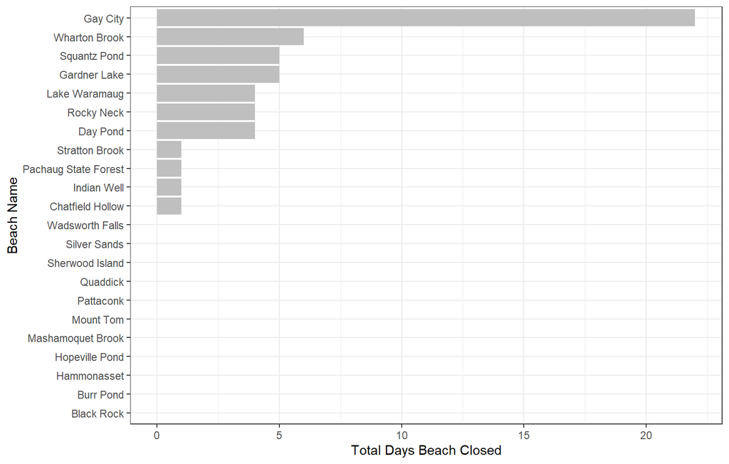

## Historical Closure Data 1998 - 2021

### Closures

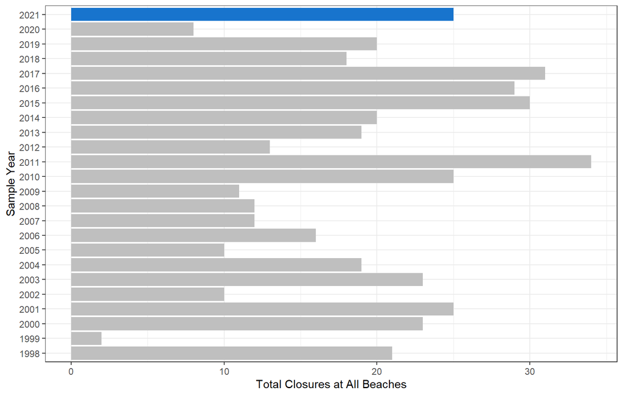

1. 2011 - Results impacted by Hurricane Irene (last week of beach season)  
2. 2017 - Results impacted by change in sampling protocol  
(samples collected Thursday/Friday led to an increase in weekend closures)  
3. 2018 - Wharton Brook swimming area closed for entire 2018 season and not sampled  
4. 2020 - Results impacted by COVID-19  
(inland beaches not sampled until 7/14/20, 7 inland beaches remained closed due to COVID-19 policy)  
5. 2021 - Mashamoquet Brook swimming area closed for entire 2021 season and not sampled  
6. 2022 - Mashamoquet Brook swimming area closed for entire 2022 season and not sampled

### Days Closed

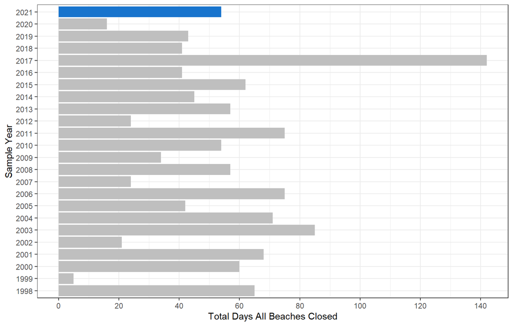

1. 2011 - Results impacted by Hurricane Irene (last week of beach season)  
2. 2017 - Results impacted by change in sampling protocol  
(samples collected Thursday/Friday led to an increase in weekend closures)  
3. 2018 - Wharton Brook swimming area closed for entire 2018 season and not sampled  
4. 2020 - Results impacted by COVID-19  
(inland beaches not sampled until 7/14/20, 7 inland beaches remained closed due to COVID-19 policy)  
5. 2021 - Mashamoquet Brook swimming area closed for entire 2021 season and not sampled  
6. 2022 - Mashamoquet Brook swimming area closed for entire 2022 season and not sampled

### Days Closed per Beach (Marine)

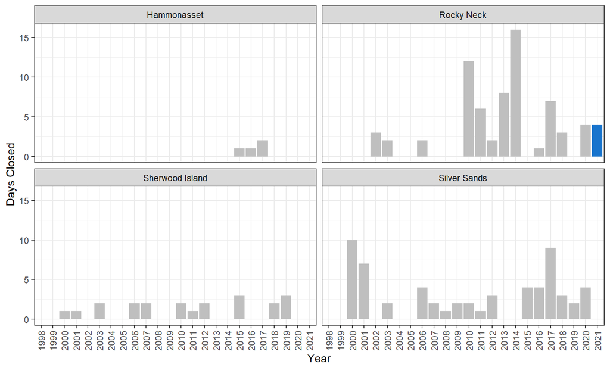

1. 2011 - Results impacted by Hurricane Irene (last week of beach season)  
2. 2017 - Results impacted by change in sampling protocol  
(samples collected Thursday/Friday led to an increase in weekend closures)  
3. 2018 - Wharton Brook swimming area closed for entire 2018 season and not sampled  
4. 2020 - Results impacted by COVID-19  
(inland beaches not sampled until 7/14/20, 7 inland beaches remained closed due to COVID-19 policy)  
5. 2021 - Mashamoquet Brook swimming area closed for entire 2021 season and not sampled  
6. 2022 - Mashamoquet Brook swimming area closed for entire 2022 season and not sampled

### Days Closed per Beach (Fresh)

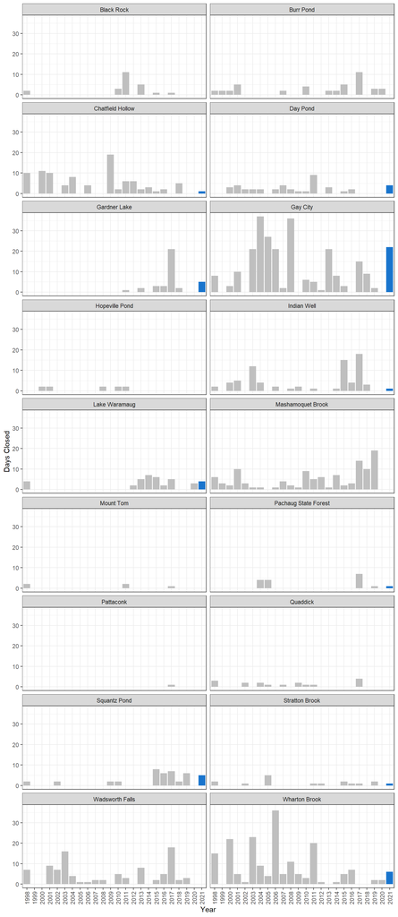

1. 2011 - Results impacted by Hurricane Irene (last week of beach season)  
2. 2017 - Results impacted by change in sampling protocol  
(samples collected Thursday/Friday led to an increase in weekend closures)  
3. 2018 - Wharton Brook swimming area closed for entire 2018 season and not sampled  
4. 2020 - Results impacted by COVID-19  
(inland beaches not sampled until 7/14/20, 7 inland beaches remained closed due to COVID-19 policy)  
5. 2021 - Mashamoquet Brook swimming area closed for entire 2021 season and not sampled  
6. 2022 - Mashamoquet Brook swimming area closed for entire 2022 season and not sampled